# CSCI E-63C Problem Set 10

# Sub-problem 1 (15 points): effect of sample size

Generate training datasets with `nObs=25`, `100` and `500` observations such that two variables are associated with the outcome as parameterized above and three are not associated and average difference between the two classes is the same as above (i.e. in the notation from the above code `nClassVars=2`, `nNoiseVars=3` and `deltaClass=1`). Obtain random forest, LDA and KNN test error rates on a (for greater stability of the results, much larger, say, with 10K observations) test dataset simulated from the same model. Describe the differences between different methods and across the sample sizes used here.

```
## [1] "Number of observations:  25"
```

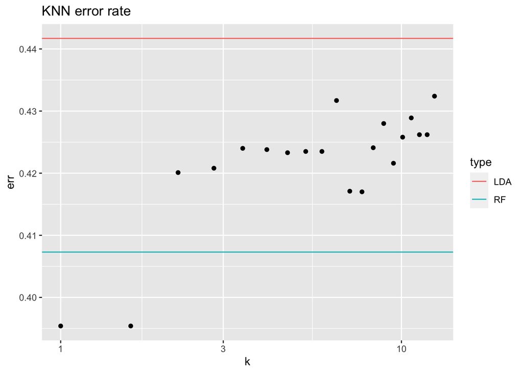

```
## [1] "Number of observations:  100"
```

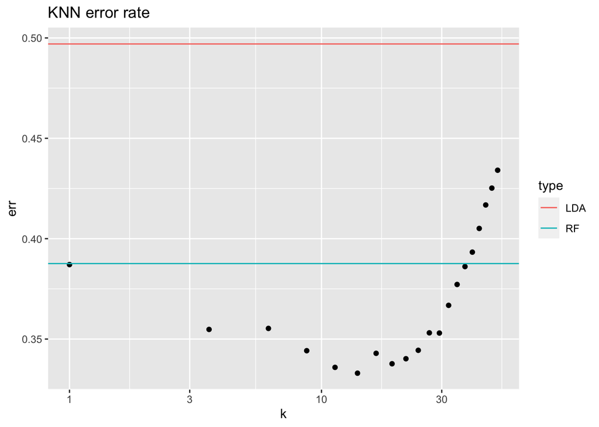

```
## [1] "Number of observations:  500"
```

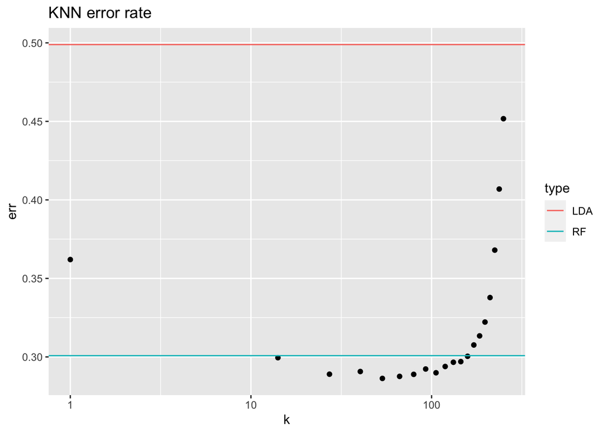

```r
# Generate the dataset, repeat 3 times
for (nObs in c(25, 100, 500)) {
  # How many predictors are associated with outcome:
  nClassVars <- 2
  # How many predictors are not:
  nNoiseVars <- 3
  # To modulate average difference between two classes' predictor values:
  deltaClass <- 1
  # Simulate training and test datasets with an interaction
  # between attribute levels associated with the outcome:
  xyzTrain <- matrix(rnorm(nObs*(nClassVars+nNoiseVars)),nrow=nObs,ncol=nClassVars+nNoiseVars)
  xyzTest <- matrix(rnorm(10000*(nClassVars+nNoiseVars)),nrow=10000,ncol=nClassVars+nNoiseVars)
  classTrain <- 1
  classTest <- 1
  for ( iTmp in 1:nClassVars ) {
    deltaTrain <- sample(deltaClass*c(-1,1),nObs,replace=TRUE)
    xyzTrain[,iTmp] <- xyzTrain[,iTmp] + deltaTrain
    classTrain <- classTrain * deltaTrain
    deltaTest <- sample(deltaClass*c(-1,1),10000,replace=TRUE)
    xyzTest[,iTmp] <- xyzTest[,iTmp] + deltaTest
    classTest <- classTest * deltaTest
  }
  classTrain <- factor(classTrain > 0)

  print(paste("Number of observations: ", nObs))
  rfRes <- randomForest(xyzTrain,classTrain)
  rfTmpTbl <- table(classTest,predict(rfRes,newdata=xyzTest))

  ldaRes <- lda(xyzTrain,classTrain)
  ldaTmpTbl <- table(classTest,predict(ldaRes,newdata=xyzTest)$class)

  dfTmp <- NULL
  for ( kTmp in seq(1,nObs/2,length.out = 20) ) {
    knnRes <- knn(xyzTrain,xyzTest,classTrain,k=kTmp)
    tmpTbl <- table(classTest,knnRes)
    dfTmp <- rbind(dfTmp,data.frame(err=1-sum(diag(tmpTbl))/sum(tmpTbl),k=kTmp))
  }
  print(ggplot(dfTmp,aes(x=k,y=err))+geom_point()+scale_x_log10()+geom_hline(aes(yintercept = err,colour=type),data=data.frame(type=c("LDA","RF"),err=c(1-sum(diag(ldaTmpTbl))/sum(ldaTmpTbl),1-sum(diag(rfTmpTbl))/sum(rfTmpTbl))))+ggtitle("KNN error rate"))
}
```

# Sub-problem 2 (15 points): effect of signal magnitude

For training datasets with `nObs=100` and `500` observations simulate data as shown above with average differences between the two classes that are same as above, half of that and twice that (i.e. `deltaClass=0.5`, `1` and `2`). Obtain and plot test error rates of random forest, LDA and KNN for each of the six (two samples sizes times three signal magnitudes) combinations of sample size and signal strengths. As before use large test dataset (e.g. 10K observations or so) for greater stability of the results. Describe the most pronounced differences across error rates for those datasets: does the increase in the number of observations impact the error rate of the models? Does change in the magnitude of signal impact their performance? Are different classifier approaches impacted in a similar way?

```
## [1] "Number of observations:  100"
```

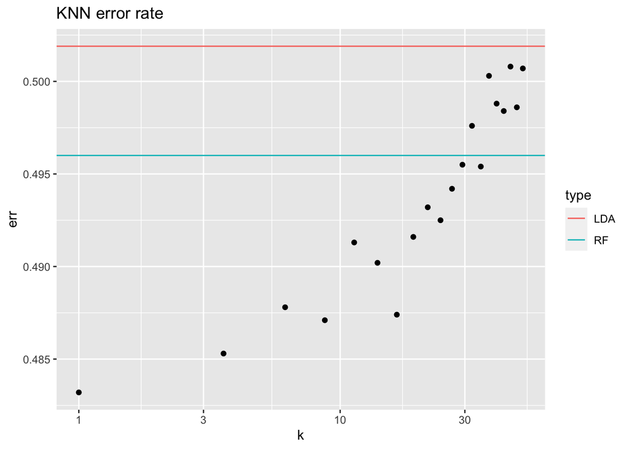

```
## [1] "Number of observations:  500"
```

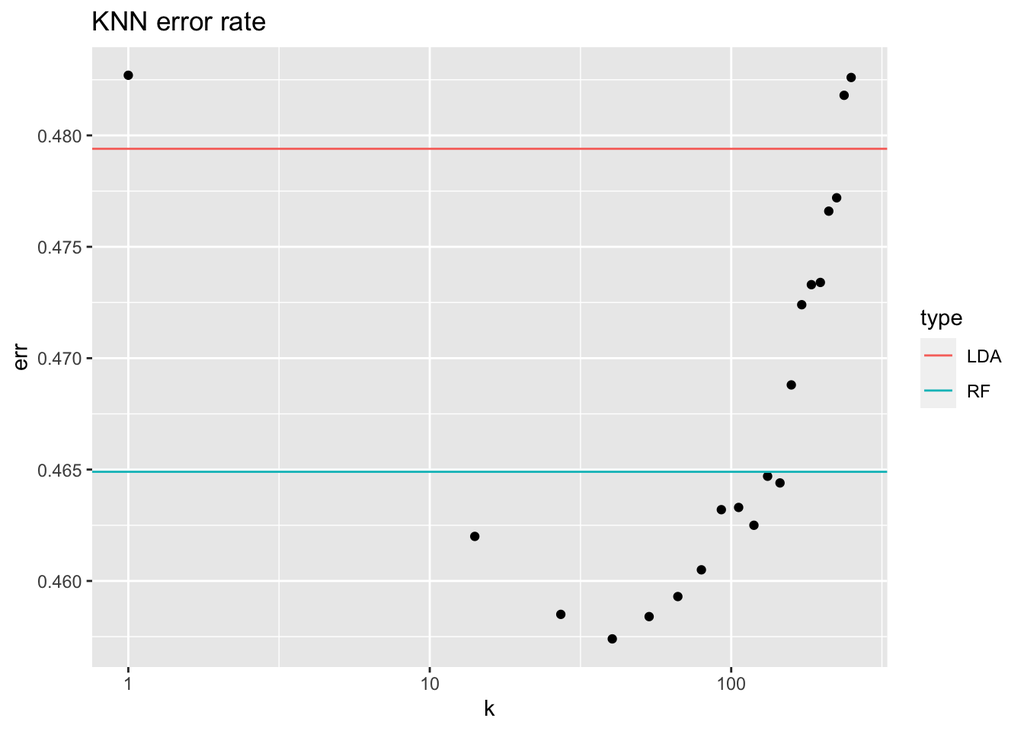

```
## [1] "Number of observations:  100"
```

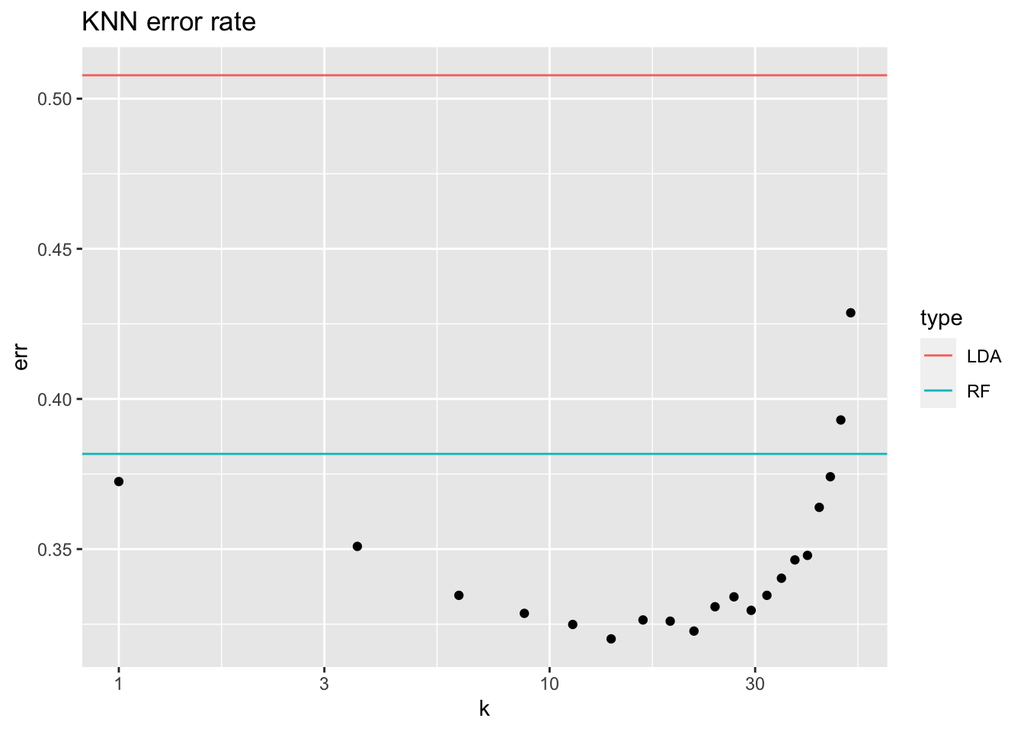

```
## [1] "Number of observations:  500"
```

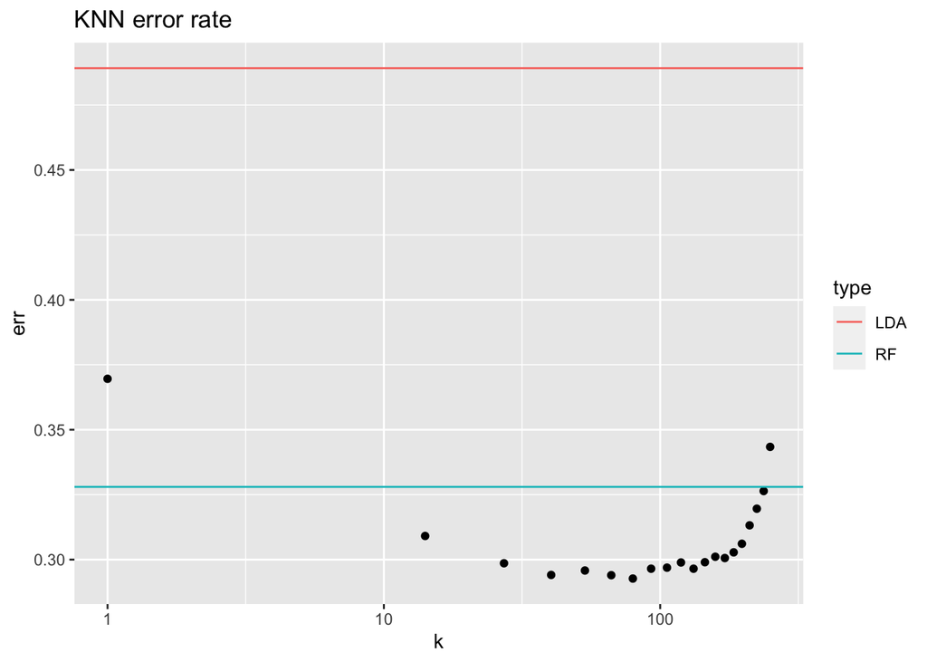

```
## [1] "Number of observations:  100"
```

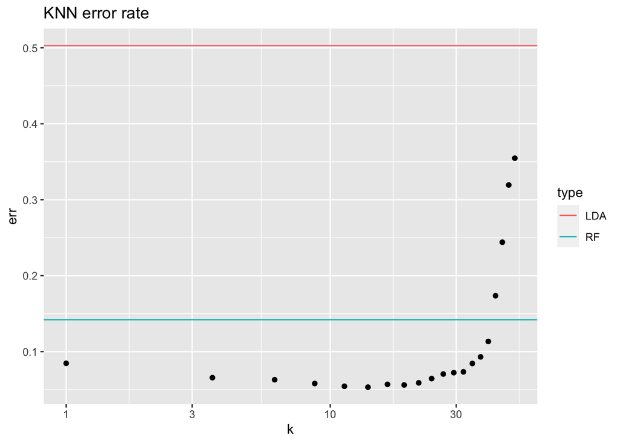

```
## [1] "Number of observations:  500"
```

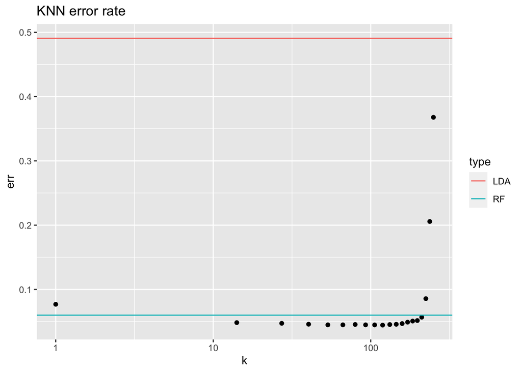

```r
for (deltaClass in c(0.5, 1, 2)) {
    # Generate the dataset, repeat 3 times
  for (nObs in c(100, 500)) {
    # How many predictors are associated with outcome:
    nClassVars <- 2
    # How many predictors are not:
    nNoiseVars <- 3
    # Simulate training and test datasets with an interaction
    # between attribute levels associated with the outcome:
    xyzTrain <- matrix(rnorm(nObs*(nClassVars+nNoiseVars)),nrow=nObs,ncol=nClassVars+nNoiseVars)
    xyzTest <- matrix(rnorm(10000*(nClassVars+nNoiseVars)),nrow=10000,ncol=nClassVars+nNoiseVars)
    classTrain <- 1
    classTest <- 1
    for ( iTmp in 1:nClassVars ) {
      deltaTrain <- sample(deltaClass*c(-1,1),nObs,replace=TRUE)
      xyzTrain[,iTmp] <- xyzTrain[,iTmp] + deltaTrain
      classTrain <- classTrain * deltaTrain
      deltaTest <- sample(deltaClass*c(-1,1),10000,replace=TRUE)
      xyzTest[,iTmp] <- xyzTest[,iTmp] + deltaTest
      classTest <- classTest * deltaTest
    }
    classTrain <- factor(classTrain > 0)

    print(paste("Number of observations: ", nObs))
    rfRes <- randomForest(xyzTrain,classTrain)
    rfTmpTbl <- table(classTest,predict(rfRes,newdata=xyzTest))
    rferror <- (rfTmpTbl[2,1]+rfTmpTbl[1,2])/sum(rfTmpTbl)

    ldaRes <- lda(xyzTrain,classTrain)
    ldaTmpTbl <- table(classTest,predict(ldaRes,newdata=xyzTest)$class)
    ldaerror <- (ldaTmpTbl[2,1]+ldaTmpTbl[1,2])/sum(ldaTmpTbl)

    dfTmp <- NULL
    for ( kTmp in seq(1,nObs/2,length.out = 20) ) {
      knnRes <- knn(xyzTrain,xyzTest,classTrain,k=kTmp)
      tmpTbl <- table(classTest,knnRes)
      dfTmp <- rbind(dfTmp,data.frame(err=1-sum(diag(tmpTbl))/sum(tmpTbl),k=kTmp))
    }
    print(ggplot(dfTmp,aes(x=k,y=err))+geom_point()+scale_x_log10()+geom_hline(aes(yintercept = err,colour=type),data=data.frame(type=c("LDA","RF"),err=c(1-sum(diag(ldaTmpTbl))/sum(ldaTmpTbl),1-sum(diag(rfTmpTbl))/sum(rfTmpTbl))))+ggtitle("KNN error rate"))
  }
}
```

# Sub-problem 3 (15 points): varying counts of predictors

For all possible pairwise combinations of the numbers of variables associated with outcome (`nClassVars=2` and `5`) and those not associated with the outcome (`nNoiseVars=1`, `3` and `10`) – six pairwise combinations in total – obtain and present graphically test errors from random forest, LDA and KNN. Choose signal magnitude (`deltaClass`) and training data sample size so that this simulation yields non-trivial results – noticeable variability in the error rates across those six pairwise combinations of attribute counts. Describe the results: what is the impact of the increase of the number of attributes associated with the outcome on the classifier performance? What about the number of attributes not associated with outcome - does it affect classifier error rate? Are different classifier methods affected by these simulation parameters in a similar way?

```
## [1] "Number of predictor variables:  2"
## [1] "Number of noise variables:  1"
```

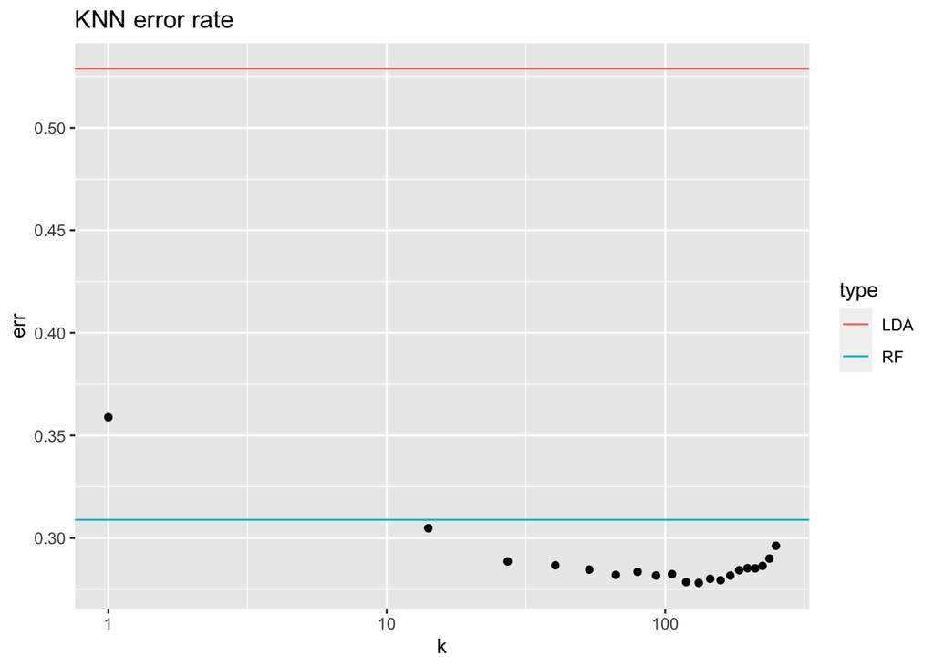

```
## [1] "Number of predictor variables:  2"
## [1] "Number of noise variables:  3"
```

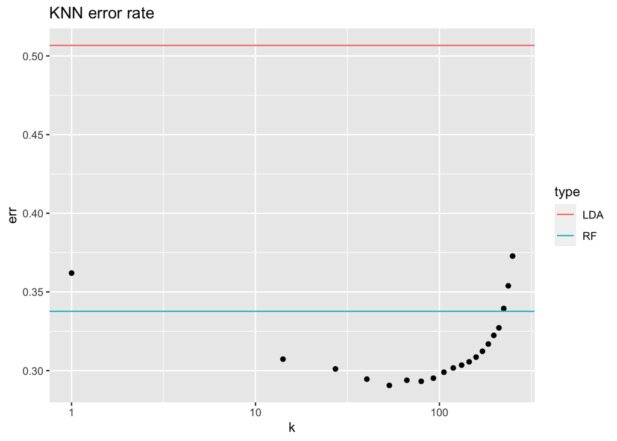

```
## [1] "Number of predictor variables:  2"
## [1] "Number of noise variables:  10"
```

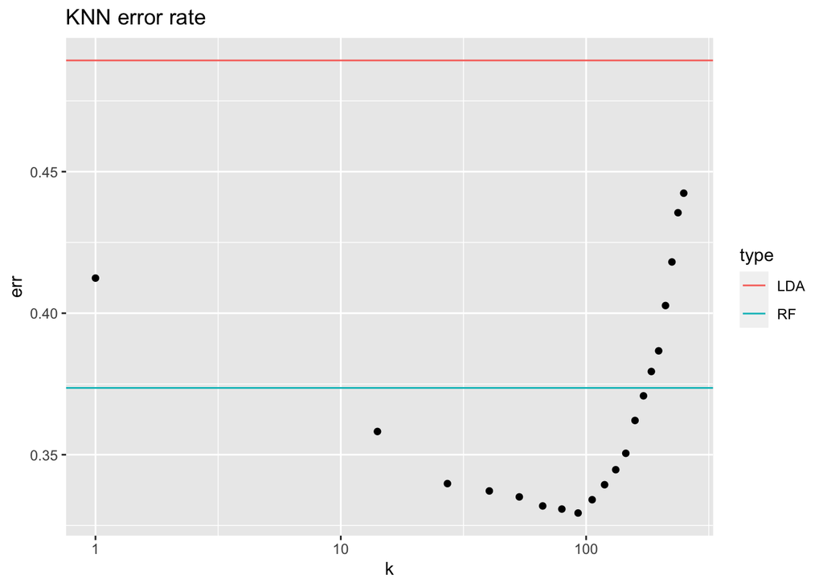

```
## [1] "Number of predictor variables:  5"
## [1] "Number of noise variables:  1"
```

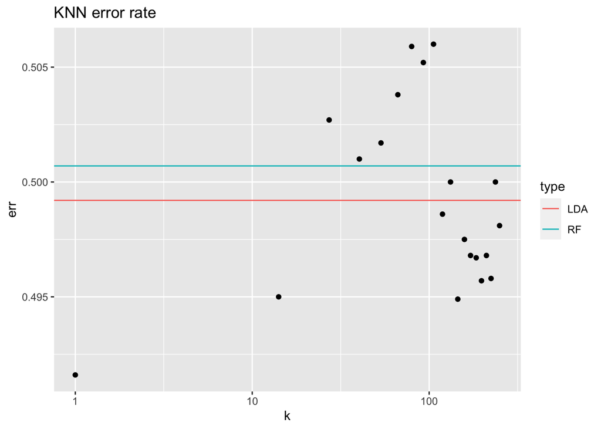

```
## [1] "Number of predictor variables:  5"
## [1] "Number of noise variables:  3"
```

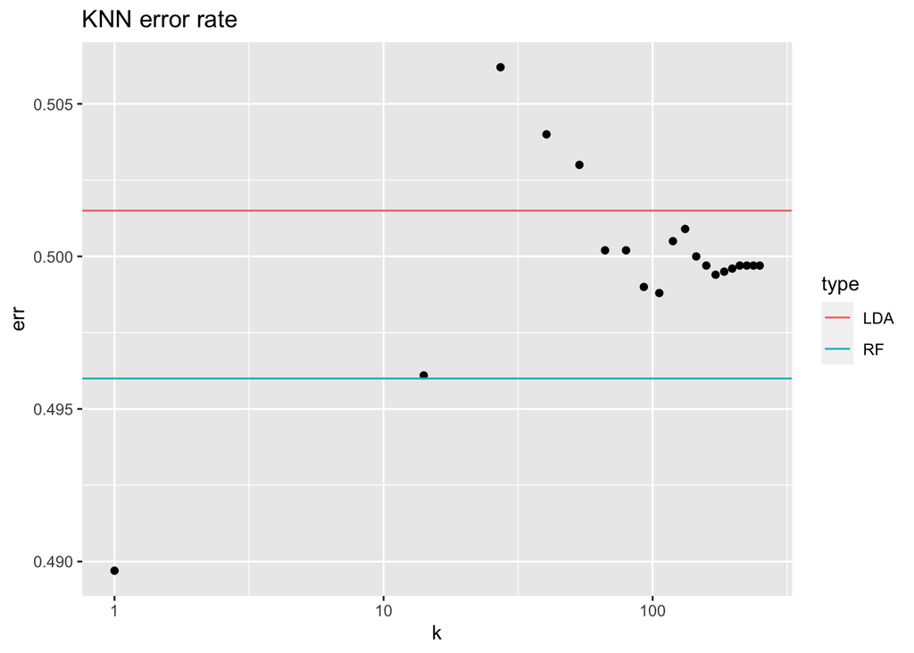

```
## [1] "Number of predictor variables:  5"
## [1] "Number of noise variables:  10"
```

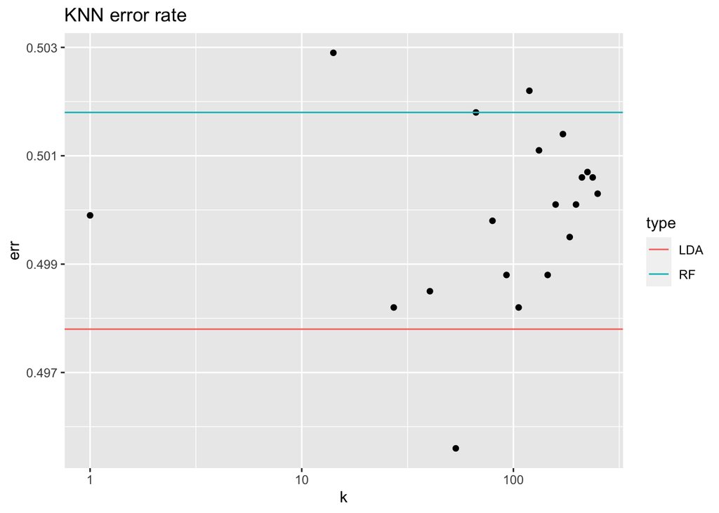

```r
for (nClassVars in c(2,5)) {
    # Generate the dataset, repeat 3 times
  for (nNoiseVars in c(1, 3, 10)) {
    # How many predictors are associated with outcome:
    deltaClass <- 1
    nObs <- 500
    # Simulate training and test datasets with an interaction
    # between attribute levels associated with the outcome:
    xyzTrain <- matrix(rnorm(nObs*(nClassVars+nNoiseVars)),nrow=nObs,ncol=nClassVars+nNoiseVars)
    xyzTest <- matrix(rnorm(10000*(nClassVars+nNoiseVars)),nrow=10000,ncol=nClassVars+nNoiseVars)
    classTrain <- 1
    classTest <- 1
    for ( iTmp in 1:nClassVars ) {
      deltaTrain <- sample(deltaClass*c(-1,1),nObs,replace=TRUE)
      xyzTrain[,iTmp] <- xyzTrain[,iTmp] + deltaTrain
      classTrain <- classTrain * deltaTrain
      deltaTest <- sample(deltaClass*c(-1,1),10000,replace=TRUE)
      xyzTest[,iTmp] <- xyzTest[,iTmp] + deltaTest
      classTest <- classTest * deltaTest
    }
    classTrain <- factor(classTrain > 0)

    print(paste("Number of predictor variables: ", nClassVars))
    print(paste("Number of noise variables: ", nNoiseVars))
    rfRes <- randomForest(xyzTrain,classTrain)
    rfTmpTbl <- table(classTest,predict(rfRes,newdata=xyzTest))
    rferror <- (rfTmpTbl[2,1]+rfTmpTbl[1,2])/sum(rfTmpTbl)

    ldaRes <- lda(xyzTrain,classTrain)
    ldaTmpTbl <- table(classTest,predict(ldaRes,newdata=xyzTest)$class)
    ldaerror <- (ldaTmpTbl[2,1]+ldaTmpTbl[1,2])/sum(ldaTmpTbl)

    dfTmp <- NULL
    for ( kTmp in seq(1,nObs/2,length.out = 20) ) {
      knnRes <- knn(xyzTrain,xyzTest,classTrain,k=kTmp)
      tmpTbl <- table(classTest,knnRes)
      dfTmp <- rbind(dfTmp,data.frame(err=1-sum(diag(tmpTbl))/sum(tmpTbl),k=kTmp))
    }
    print(ggplot(dfTmp,aes(x=k,y=err))+geom_point()+scale_x_log10()+geom_hline(aes(yintercept = err,colour=type),data=data.frame(type=c("LDA","RF"),err=c(1-sum(diag(ldaTmpTbl))/sum(ldaTmpTbl),1-sum(diag(rfTmpTbl))/sum(rfTmpTbl))))+ggtitle("KNN error rate"))
  }
}
```

# Sub-problem 4: (15 points): effect of `mtry`

Parameter `mtry` in the call to `randomForest` defines the number of predictors randomly chosen to be evaluated for their association with the outcome at each split (please see help page for `randomForest` for more details). By default for classification problem it is set as a square root of the number of predictors in the dataset. Here we will evaluate the impact of using different values of `mtry` on the error rate by random forest.

For `nObs=5000`, `deltaClass=2`, `nClassVars=3` and `nNoiseVars=20` generate data using the above approach, run `randomForest` on it with `mtry=2`, `5` and `10` and obtain corresponding test error for these three models. Describe the impact of using different values of `mtry` on the test error rate by random forest and compare it to that by LDA/KNN.

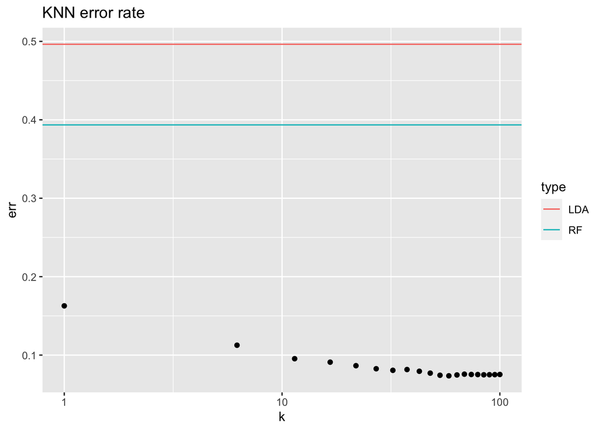

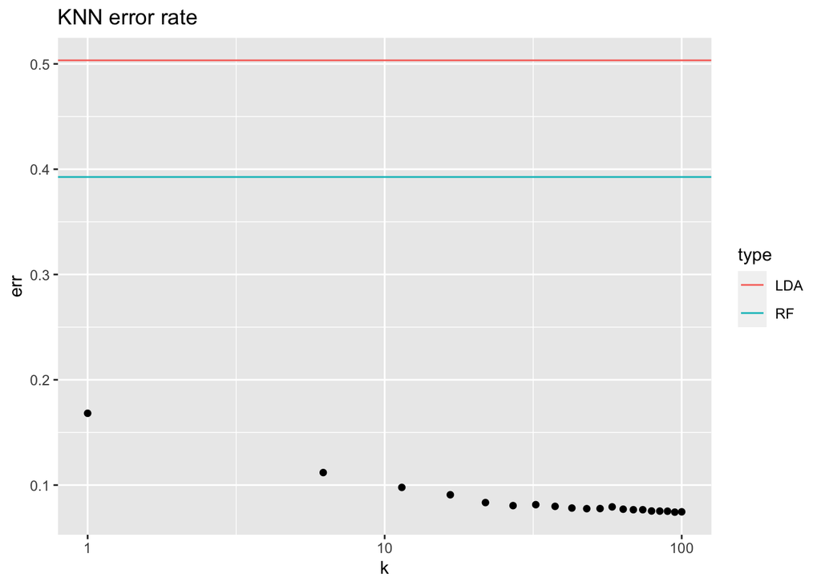

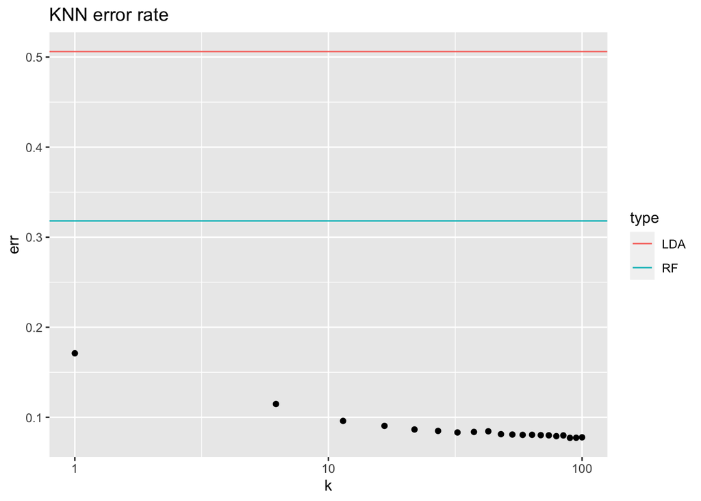

```r
# Generate the dataset, repeat 3 times
for (myMtry in c(2, 5, 10)) {
  # How many predictors are associated with outcome:
  nClassVars <- 3
  # How many predictors are not:
  nNoiseVars <- 20
  # To modulate average difference between two classes' predictor values:
  deltaClass <- 2
  nObs <- 5000
  # Simulate training and test datasets with an interaction
  # between attribute levels associated with the outcome:
  xyzTrain <- matrix(rnorm(nObs*(nClassVars+nNoiseVars)),nrow=nObs,ncol=nClassVars+nNoiseVars)
  xyzTest <- matrix(rnorm(10000*(nClassVars+nNoiseVars)),nrow=10000,ncol=nClassVars+nNoiseVars)
  classTrain <- 1
  classTest <- 1
  for ( iTmp in 1:nClassVars ) {
    deltaTrain <- sample(deltaClass*c(-1,1),nObs,replace=TRUE)
    xyzTrain[,iTmp] <- xyzTrain[,iTmp] + deltaTrain
    classTrain <- classTrain * deltaTrain
    deltaTest <- sample(deltaClass*c(-1,1),10000,replace=TRUE)
    xyzTest[,iTmp] <- xyzTest[,iTmp] + deltaTest
    classTest <- classTest * deltaTest
  }
  classTrain <- factor(classTrain > 0)

  rfRes <- randomForest(xyzTrain,classTrain, mtry = myMtry)
  rfTmpTbl <- table(classTest,predict(rfRes,newdata=xyzTest))

  ldaRes <- lda(xyzTrain,classTrain)
  ldaTmpTbl <- table(classTest,predict(ldaRes,newdata=xyzTest)$class)

  dfTmp <- NULL
  for ( kTmp in seq(1,100,length.out = 20) ) {
    knnRes <- knn(xyzTrain,xyzTest,classTrain,k=kTmp)
    tmpTbl <- table(classTest,knnRes)
    dfTmp <- rbind(dfTmp,data.frame(err=1-sum(diag(tmpTbl))/sum(tmpTbl),k=kTmp))
  }
  print(ggplot(dfTmp,aes(x=k,y=err))+geom_point()+scale_x_log10()+geom_hline(aes(yintercept = err,colour=type),data=data.frame(type=c("LDA","RF"),err=c(1-sum(diag(ldaTmpTbl))/sum(ldaTmpTbl),1-sum(diag(rfTmpTbl))/sum(rfTmpTbl))))+ggtitle("KNN error rate"))
}
```

**As the number of variables randomly sampled from at each split increases, the error of the random forest model goes down. This makes sense, as it gives us greater ability to explain outcome. However, each of these random forest models are outperformed by corresponding KNN models. This is due to the high number of noise variables (20) that cloud the random forest’s abilities to classify effectively. KNN is largely unaffected by these noise variables.**